# A Statistical Analysis of DATA2002 Students

Zi Lin Wang

# The Report Summary

The report has three main aims:

1. to answer the required sampling technique questions in section A.
2. to test a Poisson distribution fit to the COVID-19 testing data.
3. to explore connections – for DATA2002 students – between:
- Asthma and Favourite seasons
- Gender and Stress

It was concluded that Asthma and favourite season were independent factors that did not affect each other, although from a graphical analysis it was thought to be otherwise. Furthermore, females show an apparent greater mean level of stress compared to males. It must be noted with caution that these results are not highly robust, as the data set was subject to a variety of shortfalls that may have led to biases and/or invalid data points.

# The Data

A sample survey of DATA2002 students yielded the data analysed in this report. The data was provided in the form of a `.csv` file. The raw data variables contained long names and many invalid data points, which required tidying and cleaning.

## Cleaning data

The “cleaning” code was mostly provided by the DATA2002 lecturer. Changes included shortening variable names and converting the timestamp column from character into date type objects.

However, further cleaning was performed by us:

- Gender data was cleaned, such that “femail”, “f”, etc. were replaced with “female”. This allowed for a more consistent grouping by the three main entries of: `female`, `male`, and `non binary`.
- Eye colour data was standardised, with spelling converted to lowercase. Manual cleaning then replaced the mispelled entries with corrected versions.
- Height values were initially bimodally distributed, which was a surprise. Upon closer inspection, some values were clustered near `1`, which was likely entered as metres rather than centimetres.
  - The values were searched through (Stack Overflow, 2020) and converted to centimetres.

```r
### PROVIDED CLEANING
# Import data
raw = read_csv("DATA2X02 class survey 2020 (Responses) - Form responses 1.csv")

# Clean column names
x = raw %>% janitor::clean_names()
colnames(x)

colnames(x) = stringr::str_replace(string = colnames(x),
                                   pattern = "what_is_your_",
                                   replacement = "")
colnames(x) = stringr::str_replace(string = colnames(x),
                                   pattern = "on_average_how_many_hours_per_week_did_you_",
                                   replacement = "")

colnames(x)[2] = "covid_test"
colnames(x)[4] = "postcode"
colnames(x)[5] = "dentist"
colnames(x)[6] = "university_work"
colnames(x)[7] = "social_media"
colnames(x)[8] = "dog_or_cat"
colnames(x)[9] = "live_with_parents"
colnames(x)[10] = "exercising"
colnames(x)[12] = "asthma"
colnames(x)[13] = "paid_work"
colnames(x)[14] = "fav_season"
colnames(x)[16] = "height"
colnames(x)[17] = "floss_frequency"
colnames(x)[18] = "glasses"
colnames(x)[20] = "steak_preference"
colnames(x)[21] = "stress_level"

# Creating date formatted variable
x = x %>% mutate(
  postcode = as.character(postcode),
  timestamp = lubridate::dmy_hms(timestamp)
)

#### MY CLEANING
# Clean social media
x <- x %>%
    mutate(
        eye_colour = tolower(eye_colour),
        social_media = tolower(social_media),
    )
x$social_media[grepl("mess", x$social_media, ignore.case=T)] <- "messenger"
x$social_media[grepl("ins", x$social_media, ignore.case=T)] <- "instagram"
x$social_media[grepl("you", x$social_media, ignore.case=T)] <- "youtube"
x$social_media[grepl("tik", x$social_media, ignore.case=T)] <- "tiktok"
x$social_media[grepl("n/a", x$social_media, ignore.case=T)] <- "none"
x$social_media[grepl("no", x$social_media, ignore.case=T)] <- "none"
x$social_media[grepl("none", x$social_media, ignore.case=T)] <- "none"
x$social_media[grepl("emptystring_", x$social_media, ignore.case=T)] <- NA

# CLEANING EYES
x$eye_colour[grepl("balck", x$eye_colour, ignore.case=T)] <- "black"

# CLEANING HEIGHT
## djq. (2011, November 21). Conditional replacement of values in a data.frame.
index <- x$height < 80 & !is.na(x$height)
x$height[index] <- (x$height[index] * 100)

# Clean genders
f = "female"
m = "male"

x <- x %>%
  drop_na(gender, stress_level) %>%
  mutate(
    gender = tolower(gender),
    gender = recode(gender,
                    "femail" = f,
                    "female" = f,
                    "f" = f,
                    "f" = m,
                    "male" = m,
                    "M" = m,
                    "m" = m,
                    "non-binary" = "non binary")
  )
```

### Data overview

```r
kbl(x) %>%
  kable_styling(bootstrap_options = c("striped", "hover", "condensed"),
                font_size = 12,
                full_width = F,
                fixed_thead = T) %>%
  scroll_box(width = "100%", height = "400px")
```

| timestamp | covid_test | gender | postcode | dentist | university_work | social_media | dog_or_cat | live_with_parents | exercising | eye_colour | asthma | paid_work | fav_season | shoe_size | height | floss_frequency | glasses | dominant_hand | steak_preference | stress_level |
| --- | --- | --- | --- | --- | --- | --- | --- | --- | --- | --- | --- | --- | --- | --- | --- | --- | --- | --- | --- | --- |
| 2020-09-02 22:07:21 | 1 | female | 2154 | Less than 6 months | 38 | none | No | Yes | 0.0 | brown | No | 0 | Winter | 6.0 | 160.0 | Weekly | Yes | Right handed | Medium-rare | 7 |
| 2020-09-02 22:08:45 | 0 | male | 441000 | More than 2 years | 40 | youtube | No | Yes | 2.0 | black | No | 0 | Autumn | 42.0 | 178.0 | Less than once a week | No | Right handed | Medium | 9 |
| 2020-09-02 22:08:59 | 0 | male | 2120 | Less than 6 months | 3 | facebook | No | Yes | 8.0 | black | No | 2 | Autumn | 10.0 | 178.0 | Less than once a week | No | Right handed | I don’t eat beef | 4 |
| 2020-09-02 22:09:01 | 5 | male | 511442 | More than 2 years | 40 | wechat | No | Yes | 8.0 | black | No | 0 | Spring | 45.0 | 175.0 | Every day | Yes | Right handed | Medium | 9 |
| 2020-09-02 22:11:07 | 0 | male | 2042 | More than 2 years | 6 | facebook | No | Yes | 5.0 | black | Yes | 8 | Autumn | NA | NA | Every day | Yes | Right handed | Medium-well done | 2 |
| 2020-09-02 22:12:31 | 0 | male | 2046 | Between 12 months and 2 years | 30 | reddit | Yes | Yes | 4.0 | green | No | 10 | Autumn | 12.0 | 193.0 | Less than once a week | Yes | Right handed | Medium-rare | 3 |
| 2020-09-02 22:14:34 | 0 | male | 2071 | Between 6 and 12 months | 36 | NA | Yes | Yes | 5.0 | brown | Yes | 10 | Spring | 11.0 | 174.0 | Every day | No | Right handed | Medium-well done | 6 |
| 2020-09-02 22:16:17 | 0 | male | 2008 | More than 2 years | 50 | facebook | No | No | 3.0 | black | No | NA | Summer | 13.0 | 187.0 | Less than once a week | Yes | Right handed | Medium-well done | 6 |
| 2020-09-02 22:20:04 | 1 | female | 2118 | Less than 6 months | 40 | tiktok | Yes | Yes | 0.0 | brown | No | 10 | Autumn | 7.0 | 165.0 | Less than once a week | No | Right handed | Medium-rare | 5 |
| 2020-09-02 22:31:27 | 0 | male | 2009 | Less than 6 months | 20 | reddit | No | Yes | 7.0 | brown | No | 10 | Winter | 42.0 | 176.0 | Less than once a week | Yes | Right handed | Medium-rare | 7 |
| 2020-09-02 22:32:56 | 2 | female | 341000 | Less than 6 months | 50 | instagram | No | Yes | 3.0 | brown | Yes | 0 | Autumn | 5.0 | 162.0 | Less than once a week | Yes | Right handed | Medium | 6 |
| 2020-09-02 22:33:04 | 0 | male | 2195 | More than 2 years | 25 | instagram | No | Yes | 5.0 | black | No | 12 | Winter | 9.0 | 180.0 | Weekly | No | Left handed | Well done | 8 |
| 2020-09-02 22:33:20 | 0 | male | 2125 | Between 6 and 12 months | 30 | reddit | No | Yes | 2.0 | brown | Yes | 0 | Spring | 12.0 | 188.0 | Every day | Yes | Right handed | I don’t eat beef | 6 |
| 2020-09-02 22:35:03 | 0 | female | NA | Between 6 and 12 months | NA | NA | No | No | 5.0 | brown | No | 0 | Autumn | 36.0 | 164.0 | Every day | No | Right handed | Medium-rare | 4 |
| 2020-09-02 22:35:35 | 0 | female | 2007 | Between 12 months and 2 years | 20 | wechat | Yes | No | 0.0 | brown | No | 0 | Spring | 7.0 | 158.0 | Less than once a week | No | Right handed | Well done | 9 |
| 2020-09-02 22:42:30 | 0 | male | 2007 | Between 12 months and 2 years | 10 | facebook | No | Yes | 16.0 | brown | No | 0 | Autumn | 12.0 | 170.0 | Less than once a week | No | Ambidextrous | Medium-rare | 1 |
| 2020-09-02 22:43:18 | 0 | male | 2144 | Between 6 and 12 months | 40 | reddit | No | No | 1.0 | brown | No | 0 | Summer | 255.0 | 165.0 | Weekly | Yes | Right handed | Medium | 4 |
| 2020-09-02 22:44:29 | 1 | male | 2007 | Between 12 months and 2 years | 20 | club penguin | No | Yes | 0.5 | brown | No | 48 | Spring | 7.5 | 165.0 | Less than once a week | Yes | Right handed | Medium-rare | 10 |
| 2020-09-02 22:47:12 | 0 | male | 2153 | Less than 6 months | 25 | twitter | No | Yes | 5.0 | brown | No | 18 | Winter | 7.0 | 167.0 | Less than once a week | No | Right handed | Medium-rare | 6 |
| 2020-09-02 22:52:33 | 0 | female | 2077 | Between 6 and 12 months | 40 | facebook | No | Yes | 5.0 | brown | No | 10 | Autumn | 7.5 | 171.0 | Less than once a week | No | Right handed | Medium-rare | 9 |
| 2020-09-02 22:53:29 | 0 | male | 2765 | More than 2 years | 60 | messenger | No | Yes | 4.0 | black | No | 10 | Spring | 9.0 | 169.0 | Less than once a week | No | Right handed | I don’t eat beef | 5 |
| 2020-09-02 22:59:14 | 0 | female | 2050 | Between 12 months and 2 years | 40 | quora | No | No | 1.0 | dark gray | No | 5 | Autumn | NA | NA | Every day | NA | Right handed | NA | 3 |
| 2020-09-02 23:00:15 | 1 | male | 2093 | Between 12 months and 2 years | 30 | reddit | No | Yes | 2.0 | green | No | 0 | Spring | 10.0 | 170.0 | Less than once a week | No | Right handed | Medium-rare | 2 |
| 2020-09-02 23:00:28 | 0 | male | 2008 | Less than 6 months | 40 | facebook | Yes | No | 5.0 | dark brown | No | 0 | Spring | 9.5 | 175.0 | Every day | No | Right handed | Rare | 3 |
| 2020-09-02 23:29:14 | 0 | female | 2042 | Between 12 months and 2 years | 12 | youtube | Yes | No | 1.0 | dark brown | No | 0 | Spring | 38.0 | 151.0 | Most days | No | Right handed | Well done | 4 |
| 2020-09-02 23:42:26 | 1 | male | 2110 | Between 6 and 12 months | 0 | facebook | Yes | Yes | 2.0 | brown | No | 3 | Winter | 12.0 | 180.0 | Weekly | No | Right handed | Rare | 0 |
| 2020-09-02 23:45:58 | 1 | female | 2769 | Less than 6 months | 30 | instagram | No | Yes | 10.0 | brown | No | 5 | Spring | 9.5 | 169.0 | Most days | Yes | Right handed | Medium | 5 |
| 2020-09-02 23:47:52 | 0 | male | 2007 | More than 2 years | 40 | twitter | Yes | No | 10.0 | black | No | 0 | Spring | 10.0 | 183.0 | Weekly | Yes | Right handed | Well done | 4 |
| 2020-09-03 00:18:41 | 3 | female | 450000 | Between 6 and 12 months | 30 | tiktok | Yes | Yes | 14.0 | black | No | 0 | Summer | 38.0 | 163.0 | Every day | No | Right handed | Medium-well done | 8 |
| 2020-09-03 00:39:18 | 0 | male | 2135 | Less than 6 months | 4 | instagram | Yes | Yes | 7.0 | dark brown | Yes | 0 | Spring | 11.0 | 176.0 | Weekly | No | Right handed | Medium | 1 |

[output cut: 140 more lines]

# Section A — Quality of Data

*Section A discusses the problems with the sampling method that produced the data set. It covers biases, randomness, and finishes with suggestions for improvement.*

### 1. Is this a random sample of DATA2002 students?

Although the survey was posted on Ed and mentioned by Garth during a lecture, students were not randomly allocated to take the survey; rather they *optionally* took the survey. This means that the data likely does not represent a randomised selection of DATA2002 students, as students who take an optional survey are likely to share common traits that will lead to biases (discussed in A.2).

A randomised sample could have been produced by randomly generating a list of student IDs from the class list and **requiring** students to take the survey.

### 2. What are the potential biases? Which variables are most likely to be subjected to this bias?

The sample data likely does not accurately reflect the population, which is the DATA2002 cohort of 2020 Semester 2.

**Selection bias:** Respondents to the survey may have led to pre-selection for certain traits. For example, adherence: students who take optional surveys are likely to be adherers, such that they could be more likely to `floss`, `exercise`, or `study` more — variables that are part of the dataset. Students who took the survey could also simply be more engaged with the course; this can skew the variables `Hours at university` and `Hours of paid work`, as these students could potentially have spent more hours on studying than working.

**Non-response bias and Undercoverage:** Some students do not actively check Ed, therefore they would have missed the post advertising the survey. Again, this is similar to **Selection bias** as covered above. Undercoverage means that a proportion of students will not be represented by the sample, making the data incomplete and not reflect the certain parameters of the whole population.

**Measurement bias:** The wording of some questions may have been confusing, leading to misinterpretation. Such as, `"Do you wear glasses or contacts?"`. Some respondents may have thought the options were a) *do you wear glasses or wear contacts*, while others thought b) *do you wear glasses or contacts*.

**Recall bias:** Some questions asked participants to recall events from last semester. However, because memory is subjective — especially more when recalling long after the event — respondents were likely to have overestimated or underestimated some of their answers.

- For example, a student who went on their phone during study time might have overestimated the number of hours they have studied.
- `Stress level` is also subjective. Asking students to quantify their stress level can lead to varying definitions of a 0 to 10 score.

**Bad responses:** Because the survey has no method of ensuring the respondents are answering truthfully, it is likely that some students may have entered completely falsified information. To a lesser extent, this bias is also caused by mistakes when responding.

**Cause-effect bias:** There might exist a cause-effect bias between the variables of `flossing frequency` and `last time seeing dentist`. It is plausible that infrequent flossing may lead to tooth problems that require more frequent dentist visits; while simultaneously that infrequent flossers are less likely to visit the dentist for regular checkups anyway.

**Sensitive questions:** To a lesser extent, some students may not provide real postcodes due to privacy concerns. They might have also quit the survey after viewing the postcode question, which leads to undercoverage, as mentioned above.

### 3. Are there any questions that need improvement to generate useful data?

There are some questions that should restrict user input to generate tidier data:

1. Gender should be a multi-choice question for cleaner data, with genders other than `male` and `female` to be grouped as `other`.
2. Social media question can explicitly take only one answer for the subject’s favourite platform. It can also be formatted as a multi-choice question, with the most popular platforms as selections, and a `other` option for users to type more obscure platforms.
3. Height question should indicate the unit of measurement, such as `cm`.
4. Shoe size question should indicate whether to answer in US or UK size; and be restricted to only numbers
5. The same shoesize is different for men and women shoes, and thus the shoe size question should also include men or women check-boxes.
6. Eye colour should be a multi-choice (drop down menu) question to standardise capitalisation and formatting.
7. Glasses/contact lens question can be changed to: “Do you require eyesight correction?”

The modifications mentioned above will generate tidier, more robust data that better reflects the respondents’ intended answer. It removes, to a degree, the doubt and uncertainty of how to clean the data as to maximise accuracy.

# COVID-19 and Poisson

*Does the number of COVID-19 tests follow a Poisson distribution?*

This section aims to test whether a Poisson distribution is a good fit for the number of COVID-19 tests a student has had. By observing the histograms below, the number of COVID-19 tests appear to follow a Poisson distribution. COVID-19 tests peaks at 0 and is distributed with a positive skew. It follows the general shape of a Poisson distribution.

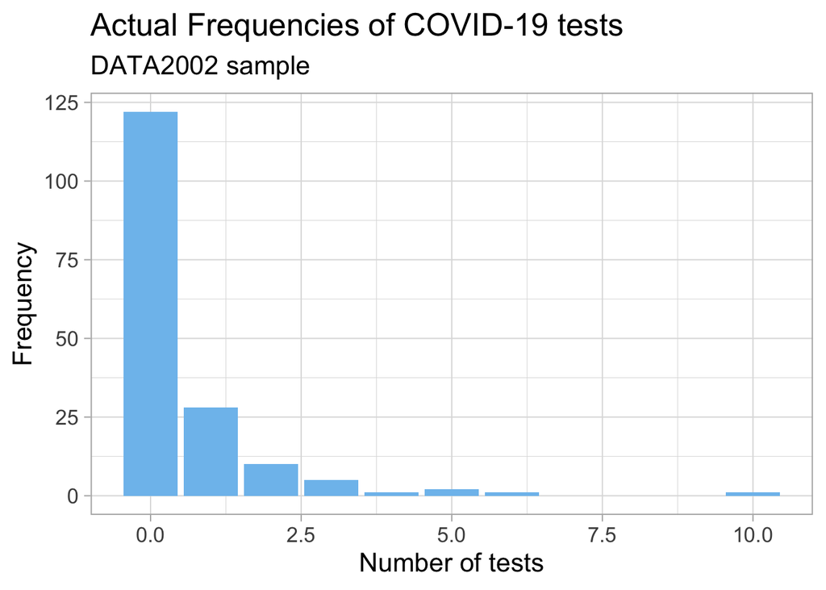

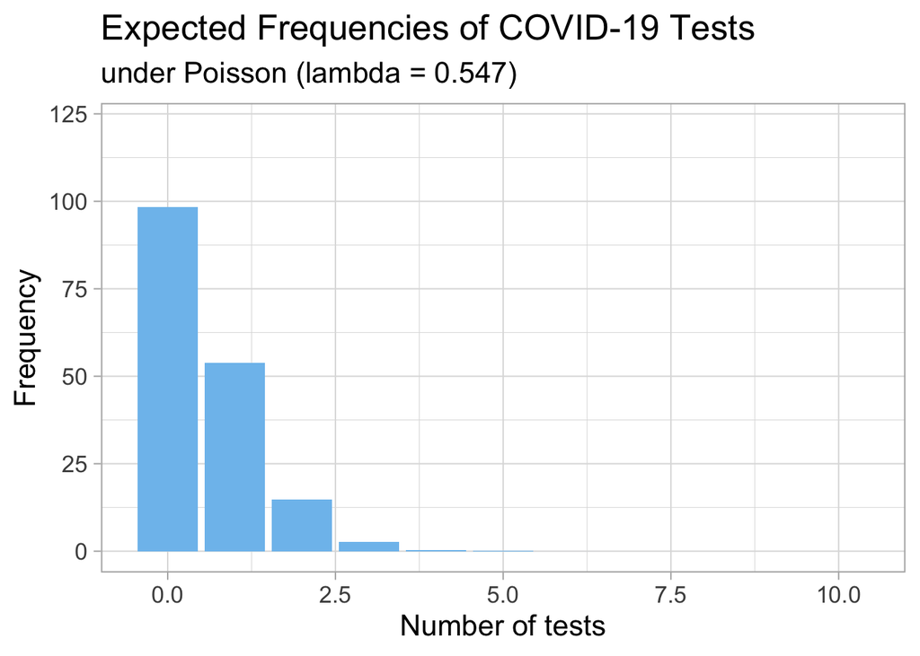

```r
# Actual distribution
covid <- x %>%
  select(covid_test) %>%
  as.data.frame()

covid.mean = mean(covid$covid_test)

# Graphing
covid.histdata <- covid %>%
  group_by(covid_test) %>%
  summarise(count = n())

covid.histdata %>%
  ggplot() +
  geom_histogram(aes(x = covid_test, y = count), stat='identity',
                 fill = 'skyblue2') +
  expand_limits(y = 122) +
  theme_light(base_size = 16) +
  labs(title = "Actual Frequencies of COVID-19 tests",
       subtitle = "DATA2002 sample",
       x = "Number of tests",
       y = "Frequency"
       )

# Poisson distribution
expPoisson = dpois(0:10, lambda = covid.mean) * length(covid$covid_test)

p = matrix(c(0:10, expPoisson), nrow = 11, ncol = 2, byrow=F)
p = as.data.frame(p)

## Graphing
p %>%
  ggplot() +
  geom_histogram(aes(x = V1, y = V2), stat='identity',
                 fill = 'skyblue2') +
  expand_limits(y = 122) +
  theme_light(base_size = 16) +
  labs(title = "Expected Frequencies of COVID-19 Tests",
       subtitle = "under Poisson (lambda = 0.547)",
       x = "Number of tests",
       y = "Frequency"
       )
```

## Hypothesis Testing

A Chi-squared test for Goodness of Fit was chosen as a suitable test for testing whether the data follows a Poisson distribution. Compared to the other Chi-squared tests for `independence` and `homogeneity`, a goodness of fit test specifically tries to compare the observed data with a mathematical distribution’s expected frequency ( *Poisson distribution in this case* )

#### Hypothesis

> **Null hypothesis:** The sample COVID-19 tests follow a poisson distribution.  
> **Alternative hypothesis:** The sample COVID-19 tests do not follow a poisson distribution.

#### Assumptions

- We can reasonably assume that each observation is independent.
  - i.e. The response of a student did not affect another student’s COVID-19 test number response.
- No more than 20% of expected frequencies for each category, meaning `number of COVID-19 tests`, can be ≤ 5.
  - After checking the data, categories were collated to ensure all expected frequencies > 5. (*see other tab for details*)

```r
covid.count = covid[,1] %>%
  factor(levels = 0:10) %>%
  table() %>%
  as.vector()

# CREATE CONTINGENCY TABLE
covid.poisson.actual = c(covid.count[1:2], sum(covid.count[3:11]))
covid.poisson.expected = c(expPoisson[1:2], sum(expPoisson[3:11]))
covid.poisson.mat = matrix(c(covid.poisson.actual, covid.poisson.expected), nrow = 2, ncol = 3, byrow = T)

colnames(covid.poisson.mat) = c(0,1,"2+")
rownames(covid.poisson.mat) = c("Actual", "Expected")

## SHOWING CONTINGENCY TABLE
covid.poisson.mat.display = matrix(c("Actual",covid.poisson.actual, "Expected",  round(covid.poisson.expected,3)), nrow = 2, ncol = 4, byrow = T)

colnames(covid.poisson.mat.display) = c("Group",0,1,"2+")
rownames(covid.poisson.mat.display) = c("Actual", "Expected")

gt(as.data.frame(covid.poisson.mat.display), rowname_col = "Group")
```

|  | 0 | 1 | 2+ |
| --- | --- | --- | --- |
| Actual | 122 | 28 | 20 |
| Expected | 98.37 | 53.814 | 17.815 |

#### Test-statistic

The `test-statistic = 10.805`, which when plotted on a Chi-squared distribution with Degrees of Freedom = 2, indicates that the p-value is `0.005`.

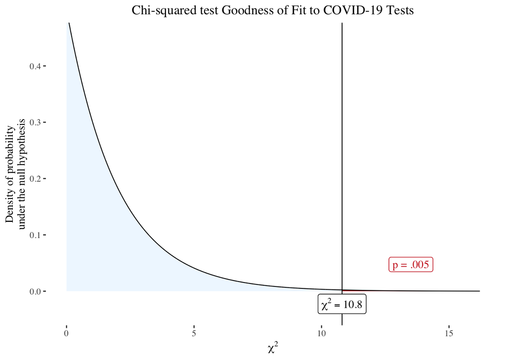

```r
covid.poisson.test = chisq.test(covid.poisson.mat, correct=F)
plotchisqtest(covid.poisson.test) +
  labs(title = "Chi-squared test Goodness of Fit to COVID-19 Tests")
```

#### P-value and Decision

Since the $\text{p-value} = 0.0045 < 0.05$ we **reject** the null hypothesis, as the probability of obtaining the test-statistic or more extreme is not likely (under our threshold of 5%). This means that under the assumption that COVID-19 tests follow a Poisson distribution, the probability of obtaining our observed data (see *Actual* row in table above) was highly unlikely.

Instead, we accept the Alternative hypothesis: **The sample data does not follow a Poisson distribution.**

```r
# GOODNESS OF FIT TEST
covid.poisson.test
```

```
##
##  Pearson's Chi-squared test
##
## data:  covid.poisson.mat
## X-squared = 10.805, df = 2, p-value = 0.004505
```

## Curating data (behind the scenes)

Using `tabyl`, a contingency table for the Poisson expected values was generated, shown below.

```r
# CHECK COCHRAN RULE
covid.poisson.expected.check = matrix(c("Expected",round(expPoisson, 2)), nrow=1,byrow=T)
colnames(covid.poisson.expected.check) = c("",0:10)
gt(as.data.frame(covid.poisson.expected.check), rowname_col = "V1")
```

|  | 0 | 1 | 2 | 3 | 4 | 5 | 6 | 7 | 8 | 9 | 10 |
| --- | --- | --- | --- | --- | --- | --- | --- | --- | --- | --- | --- |
| Expected | 98.37 | 53.81 | 14.72 | 2.68 | 0.37 | 0.04 | 0 | 0 | 0 | 0 | 0 |

We then performed a “matrix” operation to check whether each cell was > 5.

```r
expPoisson > 5
```

```
##  [1]  TRUE  TRUE  TRUE FALSE FALSE FALSE FALSE FALSE FALSE FALSE FALSE
```

Since the “3 and more” groups are fewer than 5, the “2+” groups were collated to form one group. This satisfies the second assumption for a Chi-squared Goodness of Fit test ( *refer to other tab* ).

# Asthma & Favourite season

Asthma attacks significantly increase during the autumn and winter seasons due to upper respiratory viruses that can trigger symptoms (Children’s Health Team, 2015). The combination of dry and cold weather conditions leads to worsened symptoms (Global Initiative For Asthma and National Heart, Lung, And Blood Institute, 2014).

Following this, asthma could be associated with a greater dislike towards the dry and cold weather seasons, with a greater enjoyment of spring and summer.

### Initial data analysis

From a cursory glance at the table, people with asthma appear to enjoy the spring seasons more than the other months.

*Note that the sample size for the asthma group is much smaller than the non-asthma group, which can cause the testing result to be weaker.*

```r
smy <- x %>%
  drop_na(asthma, fav_season) %>%
  tabyl(asthma, fav_season)

# MAKE A BETTER WAY OF DOING THIS
y = c(35,38,45,29,5,10,4,4)
mat = matrix(y, nrow = 2, ncol = 4, byrow=T)
gt(smy)
```

[output not shown]

The preference for spring is shown again below, graphically. Summer is the most popular season for the non-asthma group.

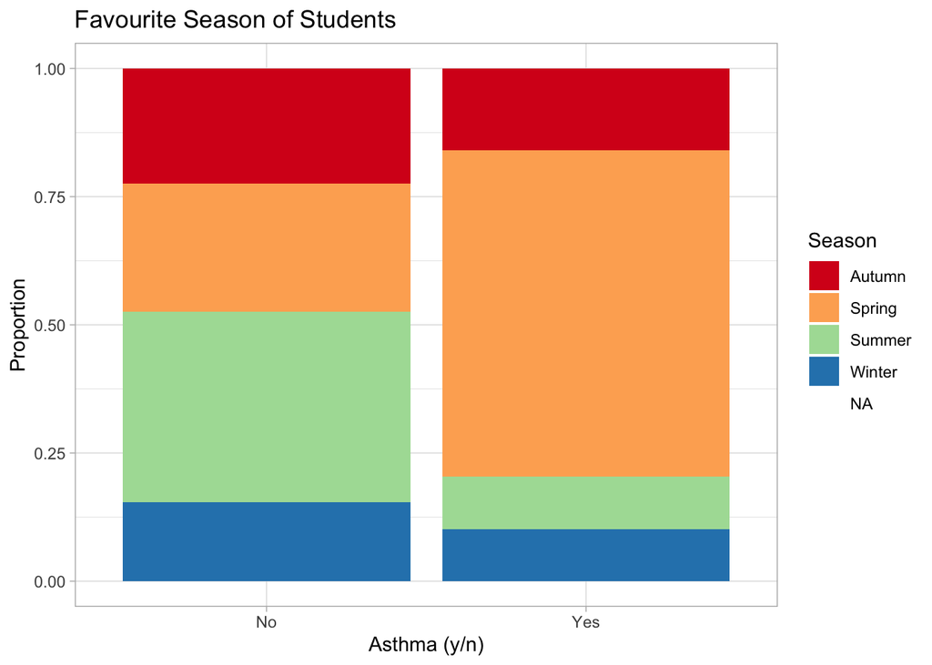

```r
x %>%
  group_by(asthma, fav_season) %>%
  transmute(count = n()) %>%
  ungroup() %>%
  ggplot(aes(x = asthma, y = count, fill = fav_season)) +
    geom_bar(stat = "identity", position = 'fill') + # POSITION IS FILL
    scale_fill_brewer(palette="Spectral") +
    labs(fill = "Season", y = "Proportion", x = "Asthma (y/n)",
         title = "Favourite Season of Students") +
  theme_light()
```

### Test for Independence

We aim to test – for DATA2002 students – whether asthma is associated with a tendency for a particular favourite season compared to the favourite season of those without asthma.

A simulated chi-squared test was chosen because the sample size is small. Using the chi-squared to approximate the test statistic for this data would be ill-suited; as it requires all expected cell frequencies to be > 5. Some expected cell frequencies are very close to 5 (shown below) and one is below 5.

Although a Fisher’s exact test could also be suitable, Monte Carlo simulation was more suitable because extending Fisher’s exact test to general `m x n` tables requires more complex assumptions.

#### Hypothesis

A significance level of 5% was chosen. The hypotheses were defined as:

> **Null hypothesis:** There is independence between people having asthma and their favourite season.  
> **Alternative hypothesis:** There is dependence between people having asthma and their favourite season. i.e.: A student’s favourite season is partially dependent on whether or not hey have asthma.

#### Assumptions

The assumption of random sampling is not satisfied here, as explained in Section A due to poor sampling. However, for the purpose of this report, let us assume the sample was random and observe the hypothesis results.

- Although one of the expected probabilities is `4.46 < 5`, we still have satisfied Cochran’s rule (no more than 20% are ≤ 5 ).
- Furthermore, since we are using simulated Monte Carlo p-values, this assumption is not nearly as important.

```r
asthma.mat = mat
yr = apply(asthma.mat, 1, sum)
yc = apply(asthma.mat, 2, sum)
yr.mat = matrix(yr, 2, 4, byrow =F)
yc.mat = matrix(yc, 2, 4, byrow=T)
ey.mat = yr.mat * yc.mat / sum(asthma.mat)
colnames(ey.mat) = c("Autumn", "Spring", "Summer", "Winter")
rownames(ey.mat) = c("No", "Yes")

ey.mat.print = matrix(c("No", round(ey.mat[1,],1),
                        "Yes", round(ey.mat[2,],1)),
                        ncol = 5,
                        nrow = 2,
                        byrow = T)
colnames(ey.mat.print) = c("Group", "Autumn", "Spring", "Summer", "Winter")
rownames(ey.mat.print) = c("No", "Yes")

temp = ey.mat.print %>%
  as.data.frame()

temp$Autumn = as.numeric(temp$Autumn)
temp$Spring = as.numeric(temp$Spring)
temp$Summer = as.numeric(temp$Summer)
temp$Winter = as.numeric(temp$Winter)

temp %>%
  adorn_totals("row") %>%
  adorn_totals("col") %>%
  gt()
```

| Group | Autumn | Spring | Summer | Winter | Total |
| --- | --- | --- | --- | --- | --- |
| No | 34.6 | 41.5 | 42.4 | 28.5 | 147 |
| Yes | 5.4 | 6.5 | 6.6 | 4.5 | 23 |
| Total | 40.0 | 48.0 | 49.0 | 33.0 | 170 |

```r
ey.mat >= 5
```

```
##     Autumn Spring Summer Winter
## No    TRUE   TRUE   TRUE   TRUE
## Yes   TRUE   TRUE   TRUE  FALSE
```

```r
set.seed(2902)
asthma_season.chisq = stats::chisq.test(mat, simulate.p.value = T, B=10000)
```

##### Test-statistic

The test-statistic for our observed data is:

$$t = 3.487$$

##### P-value

The p-value for our test-statistic is:

$$\text{p-value} = 0.3427$$

##### Simulated Chi-squared *(B = 10000)*

```r
asthma_season.chisq
```

```
##
##  Pearson's Chi-squared test with simulated p-value (based on 10000
##  replicates)
##
## data:  mat
## X-squared = 3.487, df = NA, p-value = 0.3427
```

##### *How does Monte Carlo simulations work?*

The Monte Carlo simulation will take the original marginal values (row and column totals) to generate random contingency tables. For each table, it will perform a chi-squared test of independence (using the chi-square distribution) which produces a test-statistic.

By comparing the observed sample test-statistic to the generated list, we can find the probability of getting our test-statistic *or more extreme*, which yields the p-value.

#### Results

The $\text{p-value} = 0.3427 > 0.05$. Therefore, we **retain the Null hypothesis:** there is insufficient evidence to suggest that asthma and favourite season are not independent.

i.e. **Asthma and favourite season are likely to be independent.**

The p-value indicates that under the null hypothesis (of independence), the probability for our observed frequencies to have occurred was likely — *“likely” is defined as a probability higher than our chosen threshold of 5%*. This gives us enough evidence to accept that `Asthma` and `Favourite season` are likely independent variables for DATA2002 students.

However, it should be heavily noted that this conclusion is not robust due to the sampling liabilities explained in *Section A*.

# Gender and Stress

Different genders may be associated with different levels of stress. Women are more likely than men to report having a great deal of stress (Gender and Stress, 2012).

```r
gender_filtered <- tabyl(x, gender, stress_level)
mat2 <- data.matrix(gender_filtered)

# PRINT THE TABLE
gt(gender_filtered)
```

| gender | 0 | 1 | 10 | 2 | 3 | 4 | 5 | 6 | 7 | 8 | 9 |
| --- | --- | --- | --- | --- | --- | --- | --- | --- | --- | --- | --- |
| female | 0 | 2 | 5 | 1 | 3 | 4 | 5 | 5 | 17 | 5 | 8 |
| male | 2 | 3 | 7 | 9 | 10 | 9 | 15 | 16 | 17 | 14 | 10 |
| non binary | 0 | 0 | 0 | 0 | 0 | 0 | 1 | 1 | 0 | 0 | 1 |

*Note:* non-binary gendered participants were left out in analysis due to the very limited sample size and the limitations of two-sampled t-test.

### Initial data analysis

The distribution shows that the sample stress level is negatively skewed. Overall, the sampled students tend to be more stressed than not.

The **male stress mean** is `5.79` and the **female stress mean** is `6.64`. There are more male students `n = 112` than female `n = 55`, so the male sample mean will likely be more robust than the female sample mean.

#### Histogram

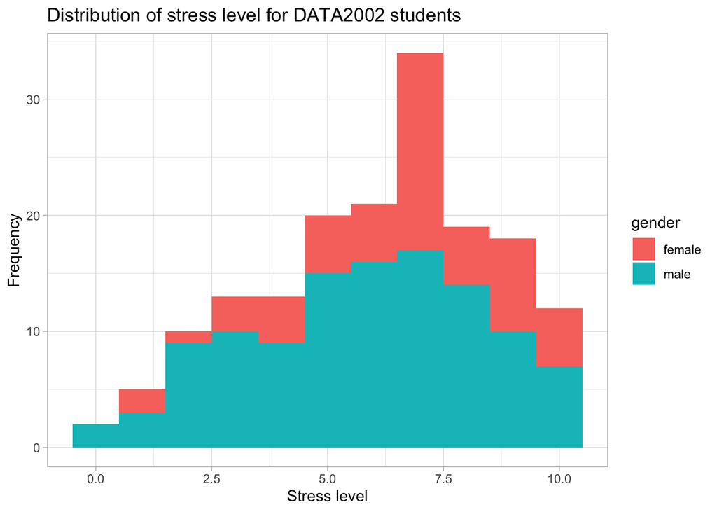

```r
# Both distribution
stress.dist.plot <- x %>%
  filter(gender != "non binary") %>%
  ggplot() +
  aes(x = stress_level, fill = gender) +
  expand_limits(x = -0.5) +
  theme_light()

stress.dist.plot +
  geom_histogram(binwidth = 1) +
  labs(title = "Distribution of stress level for DATA2002 students",
         x = "Stress level",
         y = "Frequency")
```

#### Density Plot

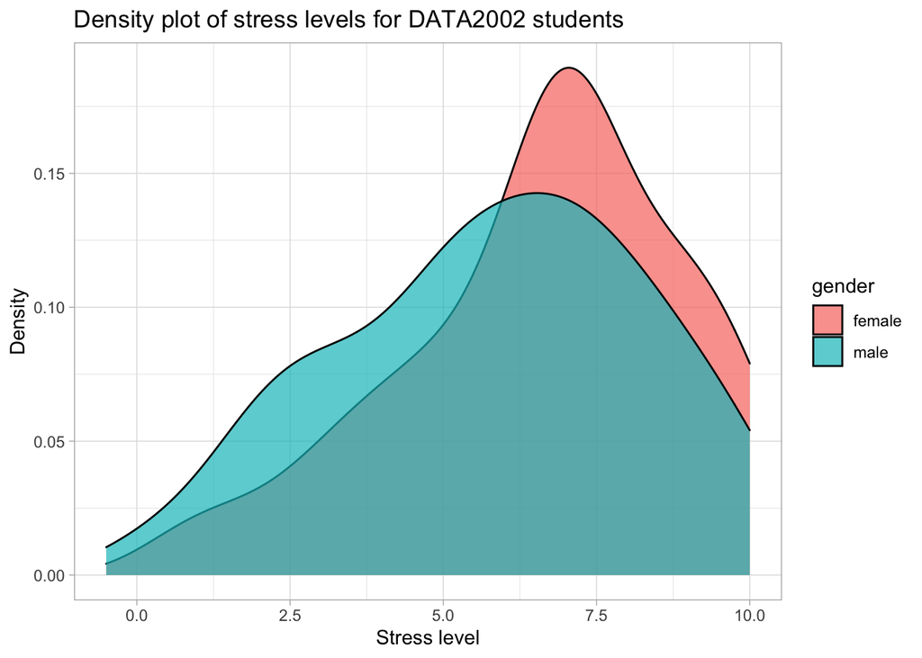

```r
stress.dist.plot +
  geom_density(alpha = 0.7) +
  labs(title = "Density plot of stress levels for DATA2002 students",
       x = "Stress level",
       y = "Density")
```

#### Male

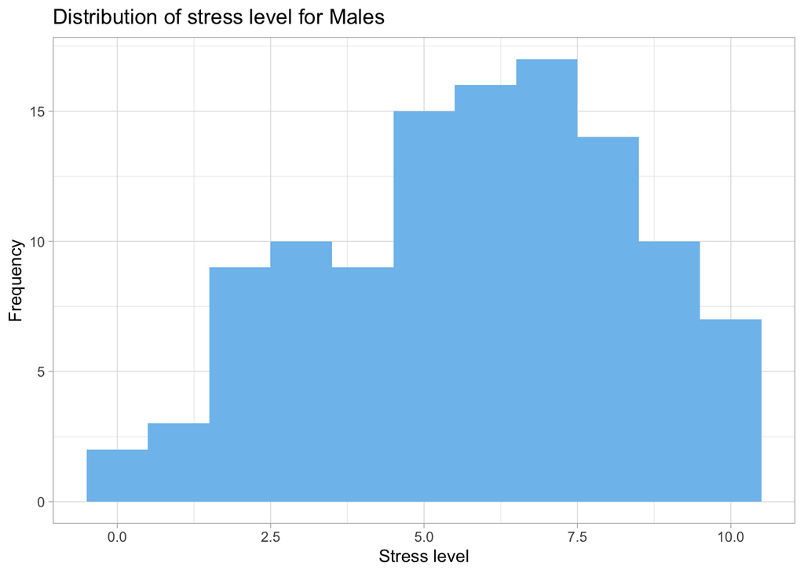

```r
# Male distribution

x %>%
  filter(gender == "male") %>%
  ggplot() +
  geom_histogram(aes(x = stress_level), binwidth = 1, fill = 'skyblue2') +
  labs(title = "Distribution of stress level for Males",
         x = "Stress level",
         y = "Frequency") +
  theme_light()
```

#### Female

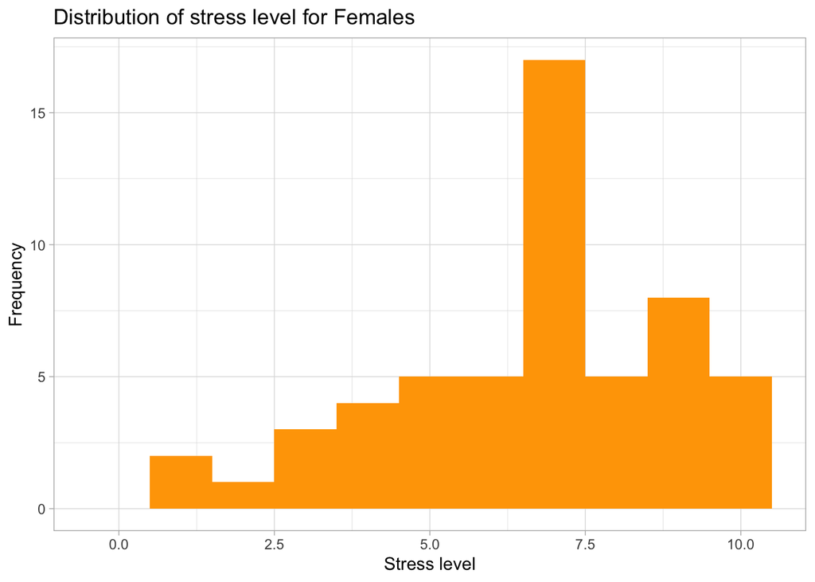

```r
# Female distribution
x %>%
  filter(gender == "female") %>%
  ggplot() +
  geom_histogram(aes(x = stress_level), binwidth = 1, fill = 'orange') +
  labs(title = "Distribution of stress level for Females",
         x = "Stress level",
         y = "Frequency") +
  expand_limits(x = -0.5) +
  theme_light()
```

### Two-sampled t-test

A two-sampled t-test was chosen as we are comparing the *mean stress level* between two populations. Since the mean of the female stress is higher than the males’, a one-tailed, greater-than test was chosen.

- Alternatively, a paired t-test would have required a dependent population and the same `n` for males and females.
- The stress level could have been treated as a categorical variable, but it would not have been ideal to perform a chi-squared test of homogeneity; as there are too many stress levels.

#### Hypothesis

A significance level of 5% was chosen. The hypotheses were defined as:

> **Null hypothesis:** The mean stress of females and mean stress of males (for DATA2002 students) are the same.
> $$H_0: \ \ \mu_{male} = \mu_{female}$$
> **Alternative hypothesis:** The mean stress of females is greater than the mean stress of males (for DATA2002 students)
> $$H_1: \ \ \mu_{female} > \mu_{male}$$

#### Assumptions

To use a Two-Sampled T-test, we must satisfy the assumption of normality for each group of data. In other words, the stress levels of `males` and `females` must demonstrate that they are normally distributed.

Let `M` be the mean of the random variable for male stress level, and `F` be that for female stress level.

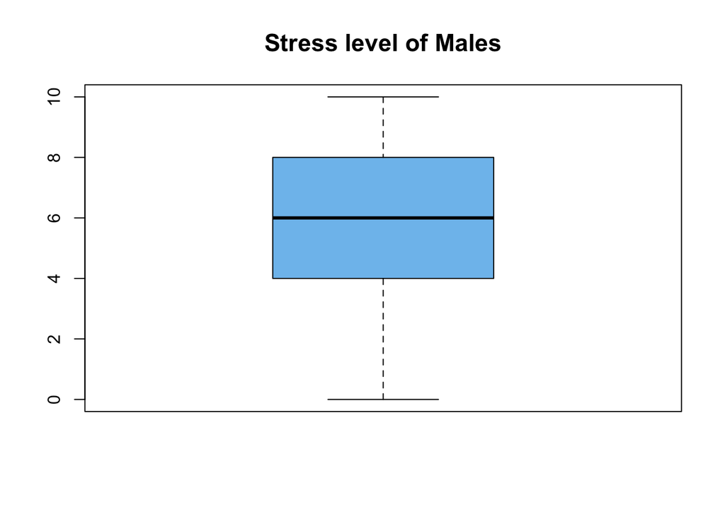

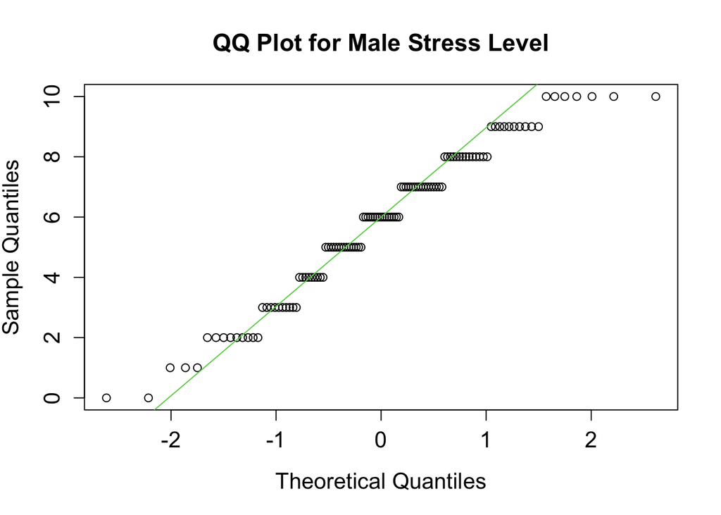

```r
boxplot(stress.male, main = "Stress level of Males", col = "skyblue2",
       cex.main= 1.4)
qqnorm(stress.male, main = "QQ Plot for Male Stress Level",
       cex.main= 1.4,
       cex.axis=1.3,
       cex.lab = 1.3); qqline(stress.male, col = 3)
```

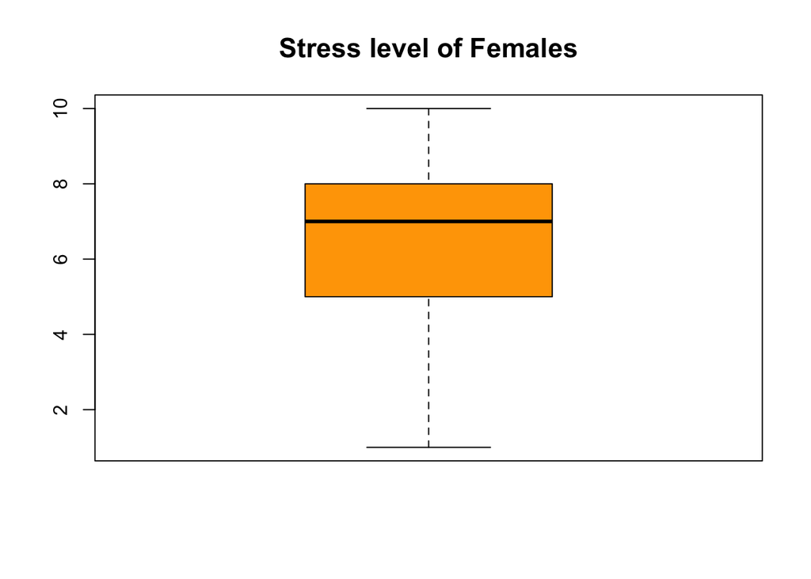

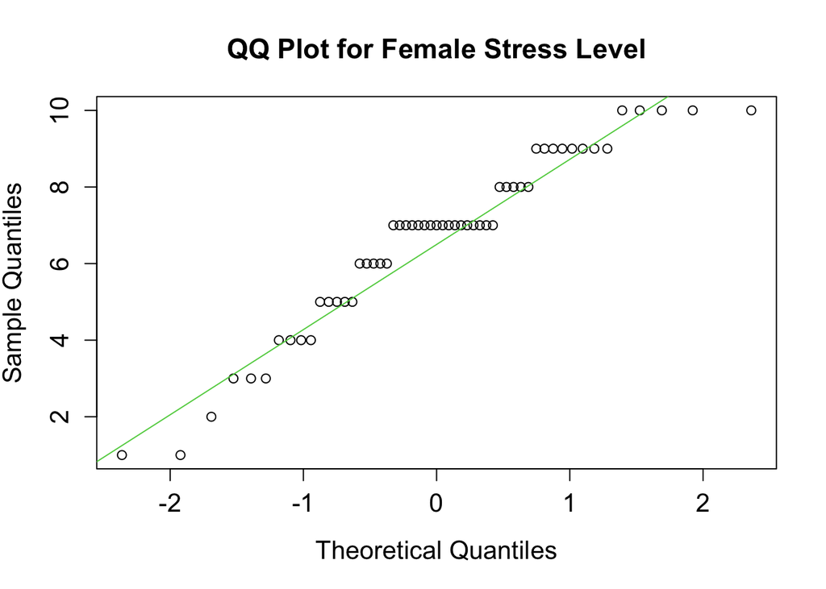

```r
boxplot(stress.female, main = "Stress level of Females", col = "orange",
       cex.main= 1.4)
qqnorm(stress.female, main = "QQ Plot for Female Stress Level",
       cex.main= 1.4,
       cex.axis=1.3,
       cex.lab = 1.3); qqline(stress.female, col = 3)
```

`M` appears to be normally distributed, as per the roughly symmetrical boxplot; the QQ plot diagram is approximately a straight line except towards the higher ends.

`F` might not be normally distributed, as the boxplot is not symmetrical (as well as the histograms above). Furthermore, the QQ plot is not aligned with the normal line, as indicated by the mismatch at the extreme quantiles

The other important assumption is **equal variance** between the two samples. However, the variances are not equal:

```r
sd(stress.male)^2 # Female
sd(stress.female)^2   # Male
```

$$\text{male}_{Var} = 6.32$$
$$\text{female}_{Var} = 5.20$$
This problem is mitigated by employing the Welch Two-sample t-test instead. The variance used to generate the Welch test-statistic uses the linear combination of the `M` and `F` variance.

$$\text{Welch test-statistic} = \frac{\bar F - \bar M}{\sqrt{\frac{S_F^2}{n_F}+\frac{S_M^2}{n_M}}}\,.$$

Lastly, we cannot assume that there was random sampling due to poor sampling as outlined in *Section A*, but for the purpose of this report this assumption will be taken as satisfied.

#### Welch Two sample t-test (one-tailed)

##### Test-statistic

The test-statistic calculated is:

$$t = 2.166$$
Shown on a probability distribution, we can visually observe the probability of obtaining this `t-statistic` *or more extreme*:

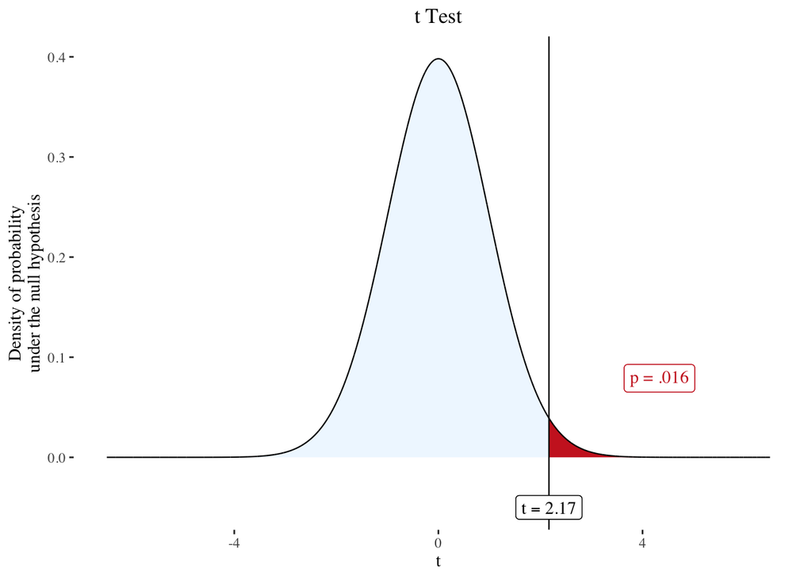

```r
welch <- t.test(stress.female, stress.male, alternative = "greater", var.equal = F, conf.level = 0.05)
plotttest(welch)
```

##### P-value & Conclusion

Due to the small $\text{p-value} = 0.01617 < 0.05$ we **reject the null hypothesis** and say: at the 5% significance level, **the mean stress of females is greater than the mean stress of males** (for DATA2002 students).

A low probability suggests that: under the null hypothesis (where we assume the means are equal), it was *unlikely* to have obtained our observed mean values of stress for each gender. “Unlikely” is defined as any probability below our significance level of *5%*. Thus, we have sufficient evidence to reject the null hypothesis *at the 5% significance level*.

However, this conclusion lacks strength as the female sample does not demonstrate intrinsic normality. Although the central limit theorem was invoked, where `n > 30`, re-sampling and retesting is encouraged to verify this conclusion. Furthermore, the sampling techniques employed for this dataset are questionable at best.

```r
welch
```

```
##
##  Welch Two Sample t-test
##
## data:  stress.female and stress.male
## t = 2.166, df = 117.43, p-value = 0.01617
## alternative hypothesis: true difference in means is greater than 0
## 5 percent confidence interval:
##  1.485995      Inf
## sample estimates:
## mean of x mean of y
##  6.636364  5.794643
```

# Summary

The findings in this report provide only a starting point for any future inquiries into the relationship between Gender and Stress, or Asthma and Seasonal effects.

We’ve managed to show that, for DATA2002 students, stress levels of females are ‘significantly’ greater than that of males. This information may aid educators, and students alike, to better direct resources to help those who need it most, ensuring our community is more supportive than ever.

On the other hand, although ‘Asthma’ and ‘Favourite season’ may appear as a ‘trivial’ matter to some, the relationship is worthy of further analysis. Seasonal effects strongly influence the epidemiology of diseases such as influenza (Yang et al., 2009). Thus, this relationship can potentially manifest as noticeable dislike among at-risk groups for the cold and dry seasons.

On a final note, we strongly remark that the conclusions reached by this report are not highly vigorous or robust — mainly due to the problematic sampling methods employed by the data provider. However, we hope that by satisfying the necessary assumptions, that our testing methods have enabled our conclusions to be as accurate as possible, given the situation.

# References

- R Packages. `tidyverse`, `janitor`, `ggplot2`, `gt`, `plotly`, `nhstplot`, and `kableExtra`.
- Stack Overflow. [online] https://stackoverflow.com/questions/8214303/conditional-replacement-of-values-in-a-data-frame
- DATA2002 Lecturer (2020). Code for cleaning data.
- Children’s Health Team (2015). Why Fall Is Worst Season for Your Child’s Asthma. [online] Health Essentials from Cleveland Clinic. Available at: https://health.clevelandclinic.org/why-fall-is-worst-season-for-your-childs-asthma/ [Accessed 21 Sep. 2020].
- Global Initiative For Asthma and National Heart, Lung, And Blood Institute (2014). Global initiative for asthma: global strategy for asthma management and prevention. Bethsda, Md: U.S. Dept. Of Health And Human Services, Public Health Service.
- Gender and Stress (2012). Gender and Stress. [online] https://www.apa.org. Available at: https://www.apa.org/news/press/releases/stress/2010/gender-stress [Accessed 21 Sep. 2020]
- Yang, L., Wong, C. M., Chan, K. P., Chau, P. Y. K., Ou, C. Q., Chan, K. H., & Peiris, J. M. (2009). Seasonal effects of influenza on mortality in a subtropical city. BMC Infectious Diseases, 9(1). https://doi.org/10.1186/1471-2334-9-133